# Super Learner Demonstration

David Benkeser

March 25, 2016

## Introduction

In this demonstration, we will illustrate the basic functionality of the `SuperLearner` using data from the SMOCC study included in the `brokenstick` package. We will illustrate how to fit a basic Super Learner ensemble using default algorithms, as well as how to check the performance of the Super Learner relative to competitor methods. We also illustrate how user-written algorithms can be incorporated into Super Learner estimation and how screening algorithms can also be incorporated.

## Basic Super Learner Functionality

We begin by illustrating a simple execution of the Super Learner function using the SMOCC data and default algorithms. Start by loading the necessary packages:

```r
require(hbgd)
require(SuperLearner)
```

For consistency, we will begin by formatting the SMOCC data to be compatible with the `hbgd` package:

```r
smcFull <- brokenstick::smocc.hgtwgt
# fix subjid and agedays names
names(smcFull)[2] <- "subjid"
names(smcFull)[5] <- "agedays"
# fix sex variable ("male" -> "Male", "female" -> "Female")
smcFull$sex <- as.character(smcFull$sex)
smcFull$sex[smcFull$sex == "male"] <- "Male"
smcFull$sex[smcFull$sex == "female"] <- "Female"
# fix htcm and wtkg names
names(smcFull)[10] <- "htcm"
names(smcFull)[11] <- "wtkg"
# fix height for age z-score
names(smcFull)[12] <- "haz"
smcFull$waz <- who_wtkg2zscore(smcFull$agedays, smcFull$wtkg, smcFull$sex)
smcFull$agedays <- years2days(smcFull$agedays)
# get only the first 2000 rows
smc <- smcFull[1:2000,]
```

We will now execute a basic call to Super Learner:

```r
# Because CV is used, must set seed to have reproducible results
set.seed(12516)

# Fit the Super Learner
sl1 <- SuperLearner(
  Y=smc$htcm, # the outcome is height in centimeters
  X=data.frame(agedays=smc$agedays), # the only predictor is age in days
  id=smc$subjid, # specify id variable so CV samples full subjects
  family=gaussian(), # more on this option later
  SL.library=c("SL.glm","SL.gam","SL.loess"), # the 'library' of algorithms to use
  method="method.NNLS", # use non-negative least squares to compute ensemble (default)
  verbose=FALSE, # don't print messages about what it's doing (default)
  cvControl=list(V=10L), # use 10 fold CV (default)
)
```

See `?SuperLearner` for a complete description of the inputs for the `SuperLearner` function. The `family` option will be discussed when we illustrate how to write new algorithms for use in SuperLearner. The above call to `SuperLearner` used 10-fold cross validation to evaluate the algorithms `SL.glm` (linear regression model), `SL.gam` (generalized additive model), and `SL.loess` (univariate loess smoothing). Specifying `method="method.NNLS"` means that these three algorithms will be evaluated based on their mean-squared error. We can check out the results to see which weighted combination of algorithms minimized this criteria:

```r
sl1
```

```
##
## Call:
## SuperLearner(Y = smc$htcm, X = data.frame(agedays = smc$agedays), family = gaussian(),
##     SL.library = c("SL.glm", "SL.gam", "SL.loess"), method = "method.NNLS",
##     id = smc$subjid, verbose = FALSE, cvControl = list(V = 10L))
##
##
##                   Risk       Coef
## SL.glm_All   12.992375 0.00385377
## SL.gam_All    7.896398 0.00000000
## SL.loess_All  6.741563 0.99614623
```

From the output, we see that the cross-validated risk was lowest for the SL.loess_All algorithm, which is simply the loess smoother (we will discuss why `_All` has been added to the output when we discuss screening functions below). The estimator with the lowest cross-validated risk is known as the discrete Super Learner – discrete because it only uses predictions from a single model. The best weighted combination of algorithms is known as the continuous Super Learner and in this case consists of the SL.glm_All and SL.loess_All algorithms.

We can now use a call to predict to obtain predictions for every child in the data set:

```r
# default call to predict
slPred <- predict(sl1)
# slPred is a list with two components
#   pred = continuous SL predictions
#   library.predict = predictions from each algorithm

# store the continuous SL predictions
cslPred <- slPred$pred

# get the discrete SL predictions
dslPred <- slPred$library.predict[,which(sl1$cvRisk==min(sl1$cvRisk))]
```

We can also do the same thing to get predictions using data from a new child using the `newdata` option:

```r
# predict height for random kid in full data set
newKid <- smcFull[smcFull$subjid==72053,]

# all predictions
slPredNew <- predict(sl1,newdata=data.frame(agedays=newKid$agedays))

# continuous SL prediction
cslPredNew <- slPredNew$pred

# discrete SL prediction
dslPredNew <- slPredNew$library.predict[,which(sl1$cvRisk==min(sl1$cvRisk))]
```

We can illustrate the fit with a simple plot of the observed and the predicted values:

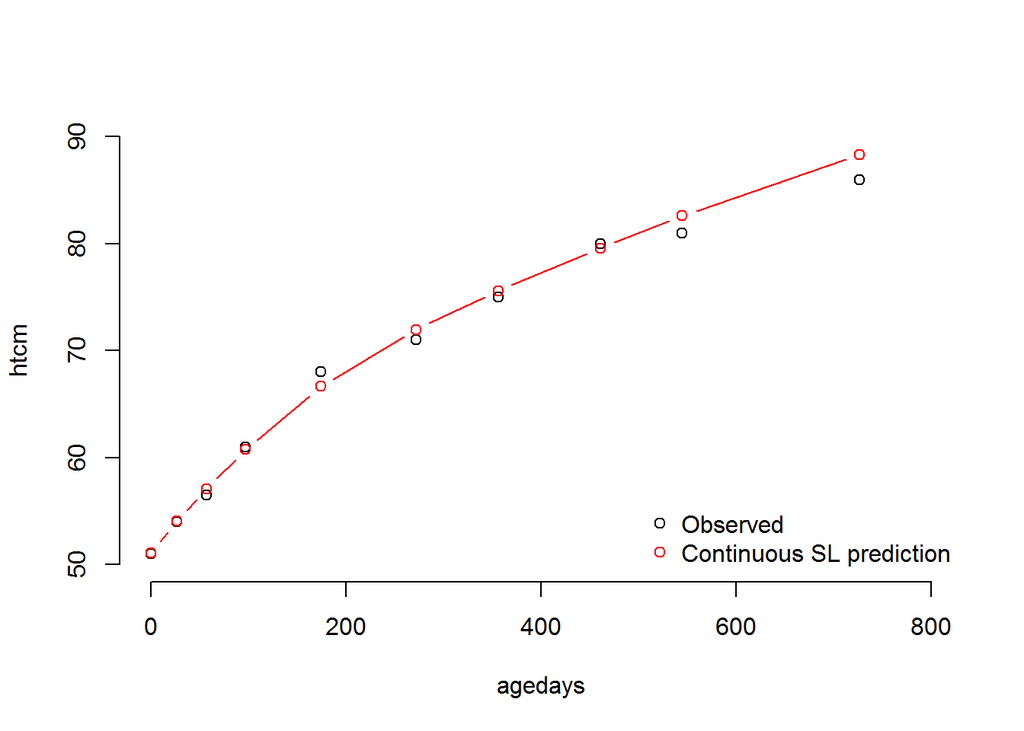

```r
plot(htcm ~ agedays, data=newKid, bty="n",pch=1, xlim=c(0,800),ylim=c(50,90))
lines(cslPredNew ~ newKid$agedays, type="b",col=2)
legend(x="bottomright",col=c(1,2), legend=c("Observed", "Continuous SL prediction"),pch=1,bty="n")
```

Finally, we note that if one wishes to access the fitted object for any of the component algorithms (fit using all the data), this can be accessed through the `fitLibrary` component of the `SuperLearner` object. For example, to access the `glm` object from the `SL.glm` algorithm, we can use:

```r
glmObject <- sl1$fitLibrary$SL.glm_All$object
summary(glmObject)
```

```
##
## Call:
## glm(formula = Y ~ ., family = family, data = X, weights = obsWeights)
##
## Deviance Residuals:
##     Min       1Q   Median       3Q      Max
## -14.120   -2.346    0.105    2.553   10.350
##
## Coefficients:
##              Estimate Std. Error t value Pr(>|t|)
## (Intercept) 5.519e+01  1.240e-01   445.2   <2e-16 ***
## agedays     5.003e-02  3.389e-04   147.6   <2e-16 ***
## ---
## Signif. codes:  0 '***' 0.001 '**' 0.01 '*' 0.05 '.' 0.1 ' ' 1
##
## (Dispersion parameter for gaussian family taken to be 12.93045)
##
##     Null deviance: 307678  on 1999  degrees of freedom
## Residual deviance:  25835  on 1998  degrees of freedom
## AIC: 10799
##
## Number of Fisher Scoring iterations: 2
```

## Evaluating the Super Learner

The `SuperLearner` package comes with an additional function to objectively evaluate the performance of the SuperLearner predictions relative to those from its component methods. This is achieved by adding an additional outer layer of V-fold cross-validation to the procedure. That is the data is split into, for example ten equally sized pieces and each algorithm is trained on nine-tenths of the data – including the Super Learner, which itself uses 10-fold cross-validation – and evaluated on the remaining piece. Each piece of data serves as the evaluation set once and the cross-validated risk of the Super Learner and each component algorithm is computed. This can be achieved through use of the `CV.SuperLearer` function:

```r
set.seed(12865)

cvsl1 <- CV.SuperLearner(
  Y=smc$htcm,
  X=data.frame(agedays=smc$agedays),
  V=10, # the number of folds for outer layer of CV (default is 20, but we'll use 10 for computational simplicity)
  id=smc$subjid,
  family=gaussian(), # more on this option later
  SL.library=c("SL.glm","SL.gam","SL.loess"),
  method="method.NNLS",
  verbose=FALSE,
  cvControl=list(V=10L), # use 10 fold CV (default)
  parallel="seq" # sequentially fit 10 folds (parallel computing is supported, but not pursued here)
)
```

The object itself is not that informative:

```r
cvsl1
```

```
##
## Call:
## CV.SuperLearner(Y = smc$htcm, X = data.frame(agedays = smc$agedays),
##     V = 10, family = gaussian(), SL.library = c("SL.glm", "SL.gam",
##         "SL.loess"), method = "method.NNLS", id = smc$subjid, verbose = FALSE,
##     cvControl = list(V = 10L), parallel = "seq")
##
##
## Cross-validated predictions from the SuperLearner:  SL.predict
##
## Cross-validated predictions from the discrete super learner (cross-validation selector):  discreteSL.predict
##
## Which library algorithm was the discrete super learner:  whichDiscreteSL
##
## Cross-validated prediction for all algorithms in the library:  library.predict
```

However, there is a nice plotting function to display the results:

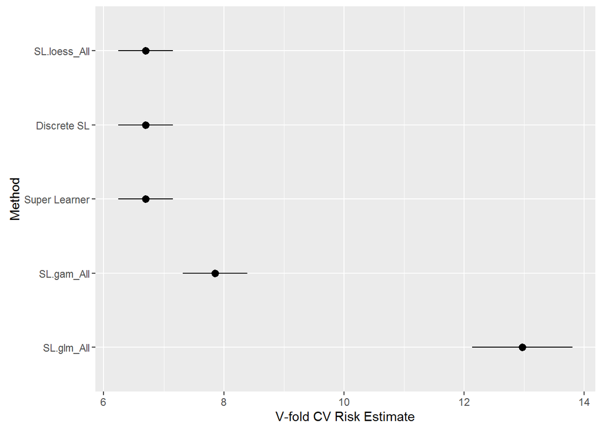

```r
plot(cvsl1)
```

The plot shows the ordered cross-validated risk estimates for each of the candidate algorithms including the discrete and continuous Super Learner.

## Writing Algorithms for SuperLearner

We now discuss how to supply new algorithms to the `SuperLearner` function. First, it is useful to check out what is included by default:

```r
listWrappers()
```

```
## All prediction algorithm wrappers in SuperLearner:
```

```
##  [1] "SL.bayesglm"         "SL.caret"            "SL.caret.rpart"
##  [4] "SL.cforest"          "SL.earth"            "SL.gam"
##  [7] "SL.gbm"              "SL.glm"              "SL.glm.interaction"
## [10] "SL.glmnet"           "SL.ipredbagg"        "SL.knn"
## [13] "SL.leekasso"         "SL.loess"            "SL.logreg"
## [16] "SL.mean"             "SL.nnet"             "SL.nnls"
## [19] "SL.polymars"         "SL.randomForest"     "SL.ridge"
## [22] "SL.rpart"            "SL.rpartPrune"       "SL.step"
## [25] "SL.step.forward"     "SL.step.interaction" "SL.stepAIC"
## [28] "SL.svm"              "SL.template"
```

```
##
## All screening algorithm wrappers in SuperLearner:
```

```
## [1] "All"
## [1] "screen.corP"           "screen.corRank"        "screen.glmnet"
## [4] "screen.randomForest"   "screen.SIS"            "screen.template"
## [7] "screen.ttest"          "write.screen.template"
```

Note that both “prediction” algorithms and “screening algorithms are shown”. We will focus on prediction algorithms for the time being. Let’s first take a look at the `SL.glm` algorithm:

```r
SL.glm
```

```
## function (Y, X, newX, family, obsWeights, ...)
## {
##     fit.glm <- glm(Y ~ ., data = X, family = family, weights = obsWeights)
##     pred <- predict(fit.glm, newdata = newX, type = "response")
##     fit <- list(object = fit.glm)
##     class(fit) <- "SL.glm"
##     out <- list(pred = pred, fit = fit)
##     return(out)
## }
## <environment: namespace:SuperLearner>
```

We note that this function takes as input: `Y`, `X`, `newX`, `family`, `obsWeights`, and other arguments via `...`. We note also that the `family` option in the call to `SuperLearner` is passed through to each of the algorithms, which allows one to, for example use a single prediction function when the outcome is both binary and continuous. The output of the prediction algorithm is a list with components `pred`, a vector of predictions computed on the `newX` object, and `fit`, basically anything else that (1) is used for predicting new values later; or (2) you would like to eventually access via the `fitLibrary` component of the `SuperLearner` object. Because this `fit` object may be used for prediction later, it is important to specify its class so that an S3 predict method can be used on the object later. Note that such a method is already included for `SL.glm`:

```r
predict.SL.glm
```

```
## function (object, newdata, ...)
## {
##     pred <- predict(object = object$object, newdata = newdata,
##         type = "response")
##     pred
## }
## <environment: namespace:SuperLearner>
```

This input/output structure is all that is needed to define a new prediction algorithm for `SuperLearner`.

As an illustration, we could write a new algorithm specifying a new `glm` algorithm that uses a natural spline for age:

```r
SL.glm.ns <- function(Y, X, newX, family, obsWeights, d=3, ...){
  # fit glm with natural spline of degree d
  fit.glm <- glm(Y ~ ns(agedays, df=d), data=X, family=family, weights=obsWeights)
  # get predictions
  pred <- predict(fit.glm, newdata=newX, type="response")
  # save the fit object
  fit <- list(object=fit.glm)
  # because this is simply a different form of glm, we can use predict.SL.glm to get predictions back, i.e. no need to write a new predict function
  class(fit) <- "SL.glm"

  out <- list(pred=pred, fit=fit)
  return(out)
}
```

We have now defined a new algorithm for use in the SuperLearner. Note that this is not an algorithm that could be used generally, as it requires `X` to have a column named `agedays`. A more general algorithm could be written that uses a natural spline for all continuous variables (see `SL.gam` for how this could be done).

Note that it is also trivial to include existing algorithms with different tuning parameter values. For example, if we wanted to include a natrual spline of degree two, we could simply define:

```r
SL.glm.ns2 <- function(...,d=2){
  SL.glm.ns(...,d=d)
}
```

These new algorithms can now be included in the Super Learner:

```r
set.seed(1256)

sl2 <- SuperLearner(
  Y=smc$htcm,
  X=data.frame(agedays=smc$agedays),
  id=smc$subjid,
  family=gaussian(),
  SL.library=c("SL.glm","SL.gam","SL.loess","SL.glm.ns","SL.glm.ns2"),
  method="method.NNLS",
  verbose=FALSE,
  cvControl=list(V=10L)
)

sl2
```

```
##
## Call:
## SuperLearner(Y = smc$htcm, X = data.frame(agedays = smc$agedays), family = gaussian(),
##     SL.library = c("SL.glm", "SL.gam", "SL.loess", "SL.glm.ns", "SL.glm.ns2"),
##     method = "method.NNLS", id = smc$subjid, verbose = FALSE, cvControl = list(V = 10L))
##
##
##
##                     Risk        Coef
## SL.glm_All     12.966265 0.002593435
## SL.gam_All      7.860187 0.000000000
## SL.loess_All    6.698600 0.931070118
## SL.glm.ns_All   6.708855 0.066336446
## SL.glm.ns2_All  7.382316 0.000000000
```

Let’s make sure that `predict.SL.glm` works for our new algorithms:

```r
slPredNew2 <- predict(sl2,newdata=data.frame(agedays=newKid$agedays))
slPredNew2
```

```
## $pred
##           [,1]
##  [1,] 51.11431
##  [2,] 54.04925
##  [3,] 57.08980
##  [4,] 60.76845
##  [5,] 66.65226
##  [6,] 71.97917
##  [7,] 75.60715
##  [8,] 79.58823
##  [9,] 82.60947
## [10,] 88.29887
##
## $library.predict
##       SL.glm_All SL.gam_All SL.loess_All SL.glm.ns_All SL.glm.ns2_All
##  [1,]   55.19156   53.24509     51.10027      51.15200       52.45081
##  [2,]   56.54194   55.13791     54.04622      53.99436       54.53832
##  [3,]   58.04399   57.23313     57.08891      57.06508       56.84634
##  [4,]   60.04489   59.98297     60.76569      60.83549       59.87170
##  [5,]   63.89684   65.03008     66.65679      66.69644       65.40910
##  [6,]   68.79950   70.77250     71.98104      72.07718       71.57135
##  [7,]   73.00230   75.02956     75.61578      75.58787       75.94859
##  [8,]   78.25397   79.59949     79.59938      79.48384       80.39034
##  [9,]   82.45677   82.81066     82.62427      82.40768       83.24410
## [10,]   91.56223   89.05401     88.29034      88.29093       87.79382
```

We now briefly discuss screening algorithms. As the name suggests, these are algorithms that specify a screening step before the prediction algorithm is applied. `SuperLearner` will apply this screening step prior to training algorithms in each of the V training steps. Let’s take a look at how screening algorithms are constructed:

```r
write.screen.template()
```

```
## screen.template <- function(Y, X, family, obsWeights, id, ...) {
##   # load required packages
##   # require('pkg')
##   if (family$family == 'gaussian') {
##
##   }
##   if (family$family == 'binomial') {
##
##   }
##   # whichVariable is a logical vector,
##   # TRUE indicates variable will be used
##   whichVariable <- rep(TRUE, ncol(X))
##   return(whichVariable)
## }
```

We see that screening algorithms take the same input as prediction algorithms, but output a logical vector with `TRUE` indicating that a column of `X` should be used in the prediction step. To illustrate why these functions are useful, we will now consider the problem of predicting height based on both age in days and sex. We will use the same algorithms as above, but now will consider each algorithm with and without an interaction between age and sex.

Let’s first set up a new data frame for use with `SuperLearner`

```r
myX <- data.frame(agedays=smc$agedays,
                  sex=as.numeric(smc$sex=="Female"),
                  int=as.numeric(smc$sex=="Female")*smc$agedays)
```

Now let’s write a screening algorithm that removes the interaction:

```r
noInt <- function(X,...){
  return(c(TRUE,TRUE,FALSE))
}
```

Now we can fit the SuperLearner using the three original algorithms each with and without the interaction. The call to `SuperLearner` is nearly identical; however, we now specify `SL.library` as a list, where each component is a vector of the form `c(predictionAlgorithm,screeningAlgorithm)`. To include the interaction, we specify the `All` screening algorithm that is included in the `SuperLearner` package.

```r
set.seed(12516)

# Fit the Super Learner
sl3 <- SuperLearner(
  Y=smc$htcm,
  X=myX,
  id=smc$subjid,
  family=gaussian(),
  SL.library=list(c("SL.glm","All"),c("SL.glm","noInt"),
                  c("SL.gam","All"),c("SL.gam","noInt"),
                  c("SL.loess","All"),c("SL.loess","noInt")),
  method="method.NNLS",
  verbose=FALSE,
  cvControl=list(V=10L)
)

sl3
```

```
##
## Call:
## SuperLearner(Y = smc$htcm, X = myX, family = gaussian(), SL.library = list(c("SL.glm",
##     "All"), c("SL.glm", "noInt"), c("SL.gam", "All"), c("SL.gam", "noInt"),
##     c("SL.loess", "All"), c("SL.loess", "noInt")), method = "method.NNLS",
##     id = smc$subjid, verbose = FALSE, cvControl = list(V = 10L))
##
##
##                     Risk      Coef
## SL.glm_All     12.386293 0.0000000
## SL.glm_noInt   12.378061 0.0000000
## SL.gam_All      7.220201 0.2146101
## SL.gam_noInt    7.291626 0.1382204
## SL.loess_All    6.741563 0.6471696
## SL.loess_noInt  6.741563 0.0000000
```

It is now apparent why the output for `sl1` contained the “_All" addendum – by default `SuperLearner` uses all the `All` screening function. This flexibility in combining screening and prediction functions allows one to easily implement many methods using different combinations of covariates.